# extraction_quality_blogpost

## Abstract

I compared field extraction extraction quality across four vision-language models on 234 chemical product labels (manufacturer, chemical name, formula, CAS number, container size). Initial metrics looked promising (60+ extractions from Qwen3-30B), but manual verification revealed systematic failures.

**Key findings:**

- Qwen3-30B generated plausible CAS numbers that weren't visible on chemical container. Cas numbers have inbuild checksum and strict formatting, the hallucinations passed both format and checksum validation.
- These hallucinations are invisible to automated validation. Only manual review catches them
- Some hallucinations were even right for the chemical but were not even present on the container.
- Qwen3-4B made obvious format errors that automated checks catch easily
- Gemini models were conservative and accurate, no hallucinations detected

**Implications:** Either implement manual review before committing data or stick to conservative models if you need fully automated pipelines. Larger Qwen3 models that ignore prompt instructions to not add knowledge outside of information provided in the image, generate plausible-looking data are more likely to pollute your extracted data, than models that make obvious mistakes.

## Context

I built an extraction app named Tabtin, where users define fields, upload images, and review extracted data before committing to their database. The app supports multiple vision-language models and includes a review UI to catch errors before they make it into actually collected data.

While testing with about 230 chemical product labels, i noticed that one of the defined fields, the CAS number field, wasnt exactly extracted as expected. Some extractions looked valid but obviously were hullicanted, which i recognized upon reviewing. The thing about the CAS Number is, they were not present on all of my chemicals containers. But generally most of Chemicals do have a CAS number, on old chemical containers they might now be written (as they are old than the agreement on providing Cas numbers). So some models (Qwen3) try to fill the fields without the number being actually present on the container. It obviously failed to provide the right number, too.

But lets go back a second:

I ran extraction on 234 chemical product labels using four vision-language models:

- **Gemini 2.5 Flash** - Google's flagship vision model (free tier: 250 calls/day)
- **Gemini 2.5 Flash Lite** - Lighter version (free tier: 1000 calls/day)
- **Qwen3-VL-30B-A3B-Instruct** - MoE model, runs locally on my 12GB GPU + system RAM, pretty fast
- **Qwen3-VL-4B-Instruct** - Dense model, fits entirely on GPU, really fast

From here on: **2.5 Flash**, **2.5 Flash Lite**, **Qwen3-30B**, and **Qwen3-4B**.

Each extraction included 5 fields (manufacturer, chemical name, formula, CAS number, container size) and pretty detailed instructions about what to do and what not to do. Most importantly here in german, but basically "Do NOT use your internal knowledge to fill in missing information. Only extract what's physically visible on the label". This should be self-explanatory in a way, as models are also asked to provide bounding boxes for each thing that they extract. And how should they provide bounding boxes with extracted value "12345" on top of text that says "tabtin", right? RIGHT?

So at first, when I saw the Qwen models catching 60+ CAS numbers while Gemini models only got 30, I got pretty exited. However, you will see that the high number of extractions for Qwen3 models are kinda meh...

**Extraction Field Configuration, which is provided to the Vision LLMs as a simple promt, based on what the user defines.** (click to expand)**

```
{
  "columns": [
    {
      "name": "Hersteller",
      "description": "Nur den Herstellernamen extrahieren, der SICHTBAR auf der Verpackung steht. NIEMALS den Hersteller erraten oder aus deinem Trainingswissen ergänzen.",
      "regex": "",
      "type": "text"
    },
    {
      "name": "Chemikalien Name",
      "description": "Der deutsche Name oder generische Name der Chemikalie. Nur Namen verwenden, die EXPLIZIT auf der Verpackung stehen du darfst aber schlecht leserliche Fotos interpretieren.",
      "regex": "",
      "type": "text"
    },
    {
      "name": "Chemikalie formel",
      "description": "Die chemische Formel EXAKT wie auf der Verpackung abgebildet. z.B. C8H18N2O6S2) Keine tiefgestellten Zahlen verwenden\nNIEMALS die Formel aus deinem Chemie-Wissen ergänzen! Nicht von CAS-Nummer oder Name auf Formel schließen. Wenn keine Formel sichtbar ist: null verwenden",
      "regex": "",
      "type": "text"
    },
    {
      "name": "Cas nummer",
      "description": "Die CAS-Nummer ist der eindeutige Identifier von Chemikalien im Format: \\d{2,7}-\\d{2}-\\d\nNUR CAS-Nummern extrahieren, die PHYSISCH auf der Verpackung sichtbar sind. Die CAS-Nummer muss dem Regex entsprechen: \\\\d{2,7}-\\\\d{2}-\\\\d\nABSOLUT VERBOTEN - Keine CAS-Nummern aus deinem Trainingswissen ergänzen! Nicht von Chemikalienname oder Formel auf CAS-Nummer schließen. Keine anderen Nummern (Artikel-Nr, LOT, Batch) als CAS-Nummer interpretieren. Keine 'wahrscheinlichen' CAS-Nummern eintragen.\nWenn KEINE CAS-Nummer auf der Verpackung sichtbar ist: IMMER null verwenden\nConfidence auf 0.0 setzen wenn du dir nicht 100% sicher bist, dass es eine CAS-Nummer ist",
      "regex": "\\d{2,7}-\\d{2}-\\d",
      "type": "text"
    },
    {
      "name": "Gebinde größe",
      "description": "Formatiere die Gebindegröße als: [Zahl] [Einheit]\nBeispiel: \"250 g\"\nGenau ein Leerzeichen zwischen Zahl und Buchstaben, sonst keine Lücken",
      "regex": "^\\d+\\s[a-zA-Z]+$",
      "type": "text"
    }
  ]
}
```

Despite explicit prohibition ("ABSOLUT VERBOTEN") in the CAS number field, some models still leaked knowledge from training data.

### Example 1: Take a look at what we expect the model to extract

This Potassium Phosphate container shows how batches with multiple images work. The front shows the container size (500g) and product name, while the back shows the chemical formula (KH2PO4) and CAS number (7778-77-0). This is what we expect. I told the model what a CAS number looks like (compare the promt, there is a Regex which explaints that Cas numbers have a certain format) and to extract it if its present and to write null if there is no CAS visible on the images. Its visible, therefore is right to extract it.

[figure not shown]

## Part 1: Gathering the Data

Processed 234 chemical labels through Tabtin using 4 different models. Accepted all extractions without review to see what each model produced. This is important. Obviously i made this app to make sure i can easily review extracted data... But in this case i approved all extracted data without reviewing.

## Part 2: The First Look - Total Extractions

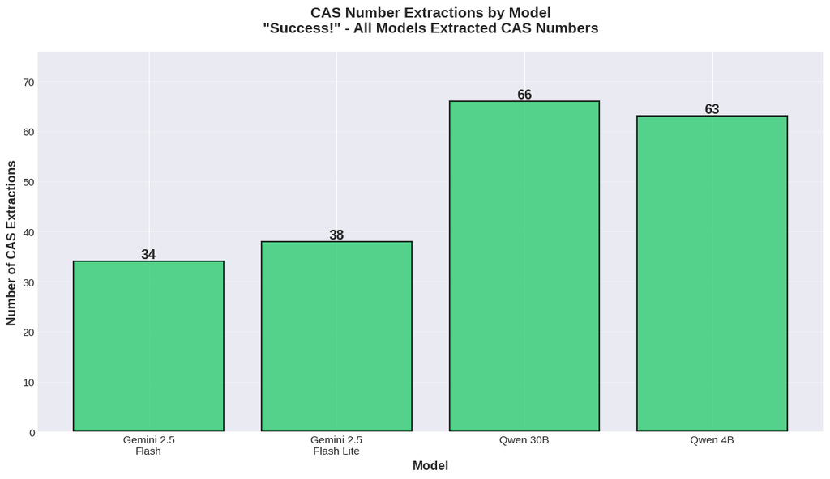

## But...

Just because a model extracted something doesn't mean it's correct.

## Part 3: Format Validation

Does the extraction even match CAS format? CAS Numbers look like: `XXXXXX-XX-X`. Or using regex `\d{2,7}-\d{2}-\d` we can use that to filter out obvious garbage. Format errors are easy to catch - if it doesn't match the pattern, it's definitely wrong

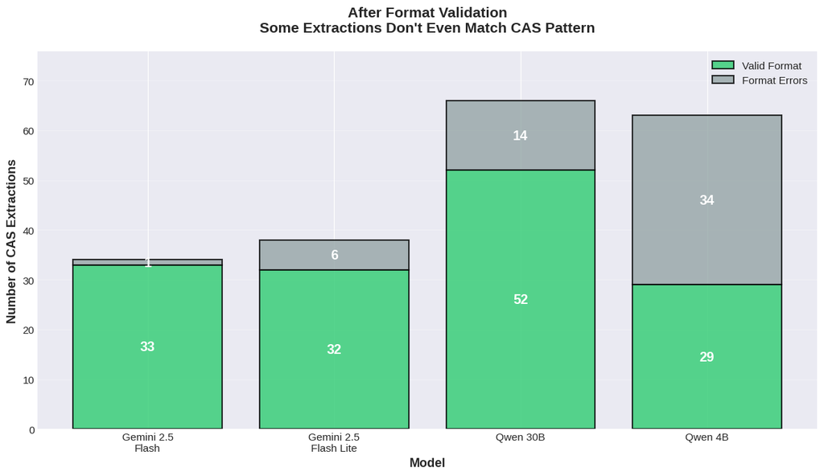

First layer of filtering reveals obvious problems: Qwen3-4B has 34 format errors out of 63 extractions (54%). These are easy to catch - strings that don't even match the basic pattern. Gemini models have very few format errors (1-6 each). Qwen3-30B sits in the middle with 14 format errors.

### Example 2: Format Error - Easy to Catch and we just got rid of them

[figure not shown]

## Part 4: Checksum Validation

CAS numbers have a mathematical checksum built in. Basically the first few numbers calulate if the last one should be any digit between 1-9. Even format-valid extractions can fail this test.

**Methodology**

**CAS checksum algorithm:**

For `7732-18-5`:

1. Remove dashes: `7732185`
2. Last digit is the check digit: `5`
3. From right to left, multiply each digit before check digit by position (starting at 1):
   - `8×1 + 1×2 + 2×3 + 3×4 + 7×5 + 7×6 = 105`
4. `105 % 10 = 5` ✓ (matches check digit)
- Invalid checksum = definitely wrong (typo or fabrication)
- Valid checksum = necessary but not sufficient (could still be hallucinated)

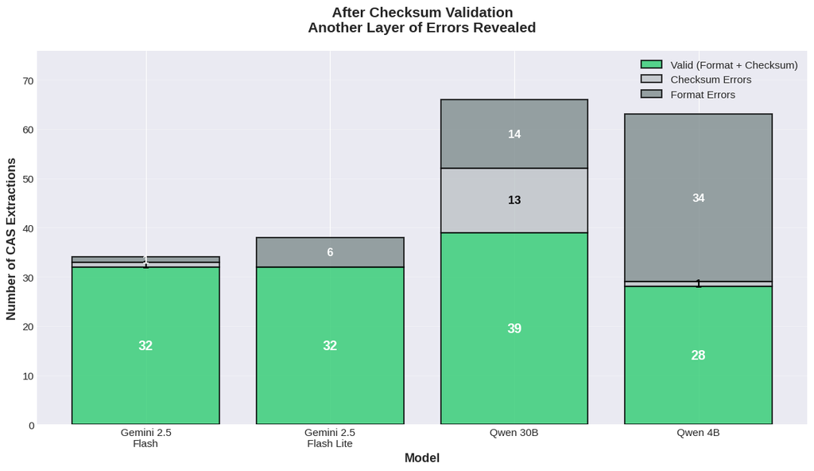

### Example 3: Checksum Error - My Favorite - Qwen thinks i dont catch 123456789

This label shows a more "subtle" error: "123456-78-9" matches the CAS format pattern perfectly, but fails checksum validation. I mean 123456789. Qwen, please, what the heck?

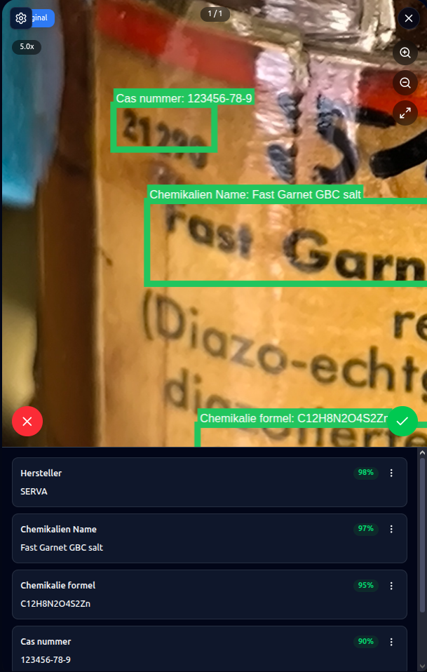

## Okay, Qwen3 30ba3b...??

So the second layer of filtering catches mathematical errors. The checksum results:

- 2.5 Flash: 1 checksum error
- 2.5 Flash Lite: 0 checksum errors
- Qwen3-4B: 1 checksum error
- **Qwen3-30B: 13 checksum errors**

The larger Qwen3 Moe model is having like 13x the error rate of its small silbing, as well as Gemini models?

If these were random OCR errors or typos, they'd be distributed evenly across models. But Qwen3-30B is consistently generating CAS numbers that match the format pattern but fail mathematical validation. Random typos don't behave like this - they'd create format errors too.

This pattern suggests the model is generating plausible-looking CAS numbers rather than just reading them. Time to dig deeper.

## Part 5: Manual Verification

After format and checksum validation, the numbers still favor Qwen3-30B: 39 valid extractions vs Gemini's 32. Even after automated filtering, the local model might be able to find more CAS numbers than Gemini.

But I needed to verify: are those extra 7 extractions actually correct? Did Gemini fail to extract CAS numbers that Qwen3-30B successfully caught?

I checked cases where Qwen3-30B was the only model to extract a CAS (all other models returned null). These should be cases where Qwen3-30B succeeded and others failed.

**The Results:**

- Manual verification revealed the opposite: none of these labels had CAS numbers visible.
- 4 knowledge leakage: Chemically correct CAS for the product, but not visible on the label. Qwen3-30B pulled it from training data. Which i specifically asked it not to do.
- 4 wrong hallucinations: Valid CAS numbers identifying completely different chemicals.

Both types passed all automated validation. These sophisticated hallucinations are invisible without manual review.

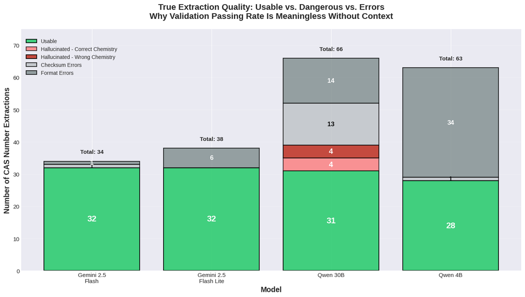

The real picture: Qwen3-30B's apparent advantage included 8 hallucinations that passed all automated validation. After accounting for these, the models are roughly equivalent in valid extractions (~31-32 each), but Gemini achieved this through conservative accuracy while Qwen3-30B mixed valid extractions with sophisticated fabrications.

### Example 4: Knowledge Leakage

This NaCl bottle has **no CAS number visible** on the label as we bottled it. Yet Qwen3-30B extracted `7647-14-5` which happens to be the chemically correct CAS number for sodium chloride. This passes format validation, checksum validation, and even chemical verification. And its actually fine... why not having the correct CAS Number, if the person bottling this Chemical forgot to label it correctly? But in this case the model got simply lucky - as you can see in the plot above, we had 4 cases where it didnt.

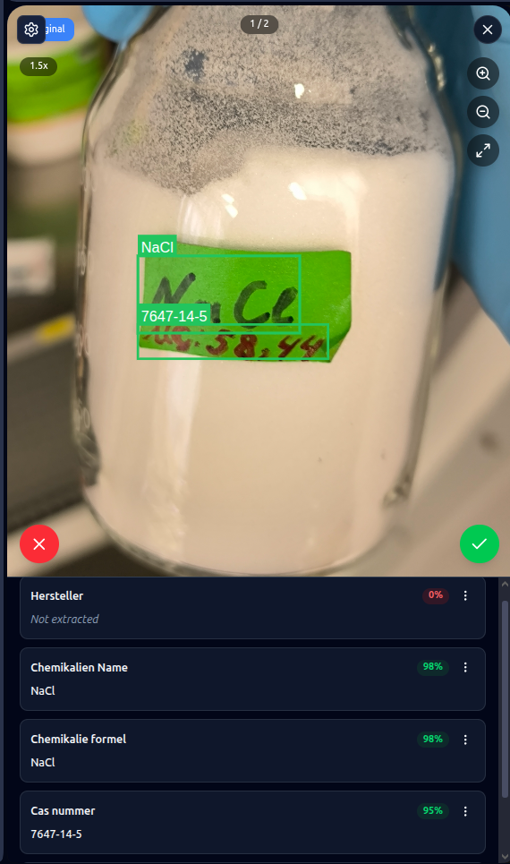

### Example 5: Another accidental Successful Extraction

Dimethylsulfoxid (DMSO) bottle with CAS number `67-68-5` not visible on the label. It is the right CAS number, but Qwen provided the knowledge and didnt take it from the image... Which i specifically asked it not to do.

[figure not shown]

## Conclusions

**Automated validation isn't enough.** Qwen3-30B passed format validation on 79% of extractions and checksum validation on 59%, but 20% of those "valid" extractions were hallucinations. Format and checksum checks catch obvious mistakes (like Qwen3-4B's 54% format error rate), but sophisticated hallucinations slip through.

**Model selection matters.** Conservative models (Gemini) produce fewer extractions but higher accuracy. Aggressive models (Qwen3-30B) produce more extractions but mix valid data with plausible fabrications and ignore prompt instructions. For my use case, I'd rather review obviously wrong extractions from Qwen3-4B than extractions from Qwen3-30B, where I'd have to take a closer look. Or if I'd use larger Qwen, be happy about the comfortable way Tabtin allows me to review data, reprocess it if I'm unhappy and all the other cool functionalities it has!

**Practical note on Tabtin compatibility:** Gemini's bounding boxes currently have issues with Tabtin's review UI, but Gemini needs less review anyway given its accuracy. Qwen's bounding boxes work great for reviewing, and Qwen performs really well when the data is actually present on labels. Users with larger datasets where images might only have portions of fields populated should be careful - Qwen3-30B's tendency to fill in missing data from training can be problematic.

**Manual review catches what automation misses.** This is why Tabtin includes a review UI before committing data to your database. If you need fully automated pipelines, stick to conservative models. If you can afford review time, the choice depends on whether you prefer filtering obvious errors (Qwen3-4B) or verifying plausible-looking data (Qwen3-30B).

**Prompt adherence varies.** Despite explicit instructions ("ABSOLUT VERBOTEN"), Qwen3-30B leaked training knowledge. Gemini models followed instructions. This matters when you're extracting data where hallucinations carry real consequences - like mislabeling chemical hazards, mixing up toxicity information, or assigning wrong safety protocols to substances.